# Auto-Manual Comparison for Regression Model course projct

Mark Nicholls

16/05/2021

## Executive Summary

I have been asked to explore the relationship between vehicle transmission and fuel economy (in Miles Per Gallon / MPG), in order to answer these questions:

- “Is automatic or manual better for MPG”
- “Quantify the difference between automatic and manual transmissions”

For this analysis I will use the mtcars data, a standard data set included with the R data analysis software. The help file for the data set provides this description of the data:

> *The data was extracted from the 1974 Motor Trend US magazine, and comprises fuel consumption and 10 aspects of automobile design and performance for 32 automobiles (1973–74 models).*

After some exploratory data analysis I decided to model how mpg changes by transmission and to compare this to a model which also takes into account vehicle weight, as I believed this to be an important factor.

My analysis shows that after accounting for vehicle weight, transmission has very little effect on mpg.

### Analysis

Lets look at the first 3 rows of data data to see what variables are available

mtcars dataset

|  | mpg | cyl | disp | hp | drat | wt | qsec | vs | am | gear | carb |
| --- | --- | --- | --- | --- | --- | --- | --- | --- | --- | --- | --- |
| Mazda RX4 | 21.0 | 6 | 160 | 110 | 3.90 | 2.620 | 16.46 | 0 | 1 | 4 | 4 |
| Mazda RX4 Wag | 21.0 | 6 | 160 | 110 | 3.90 | 2.875 | 17.02 | 0 | 1 | 4 | 4 |
| Datsun 710 | 22.8 | 4 | 108 | 93 | 3.85 | 2.320 | 18.61 | 1 | 1 | 4 | 1 |

So we have MPG and transmission included in the data set as `mpg` *MPG Miles per (US) gallon* and `am` *Transmission (0 = automatic, 1 = manual)* respectively. I also believe that vehicle weight might also be in important factor that affects mpg so so we’ll look at that one as well: `wt` *Weight (1000 lbs)*.

I plotted a box and whisker plot of mpg by transmission, and also a scatter plot of mpg by weight, with a regression line added, see Appendix: Exploratory Data Analysis plots

A first glance there appeared to be a relationship between transmission and mpg. The box and whisker plot showed automatic has a lower mean and has less variance than manual. The scatter plot showed there is also a clear relationship between weight and mpg, the greater the weight, the lower the mpg, lets model both of these relationships.

### Modelling

Model 1 is mpg by transmission, Model 2 is the same as Model 1 but with an added term for vehicle weight. I remove the intercepts from both so the estimates can be interpreted as the mean change in mpg for each term. Here are the estimates from the model.

Model Estimates

|  | Model.1 | Model.2 |
| --- | --- | --- |
| Automatic | 17.15 | 37.32 |
| Manual | 24.39 | 37.30 |
| Weight | NA | -5.35 |

I can see from this that Model 1 shows higher mpg for manual than automatic, but Model 2 shows that when you account for vehicle weight the mpg for each transmission type is very similar.

Model 1

|  | 2.5 % | 97.5 % |
| --- | --- | --- |
| trans_Automatic | 14.85 | 19.44 |
| trans_Manual | 21.62 | 27.17 |

Model 2

|  | 2.5 % | 97.5 % |
| --- | --- | --- |
| trans_Automatic | 31.07 | 43.57 |
| trans_Manual | 33.03 | 41.56 |
| weight | -6.96 | -3.74 |

After fitting the models I also looked at some residual and diagnostic plots (see Appendix: Residual / diagnostic plots)

On the Residuals vs Fitted plot for Model 2 the red dotted line is not very horizontal. This suggests that the relationship might be non-linear and a curve might fit these data better. Also the Residual vs Leverage for Model 2 shows some outliers, this suggests further investigation might be worthwhile to see if there is more information we could include to produce a more accurate model.

## Appendix

### Exploratory Data Analysis Plots

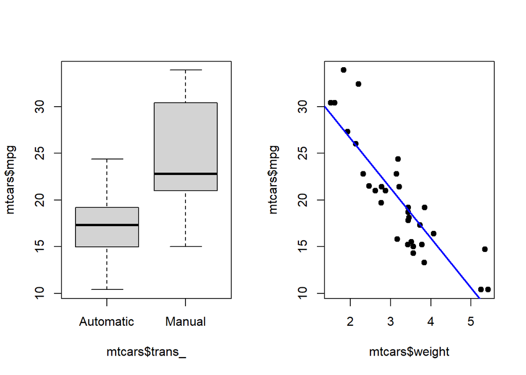

### Residual / Diagnostic plots

#### Model 1

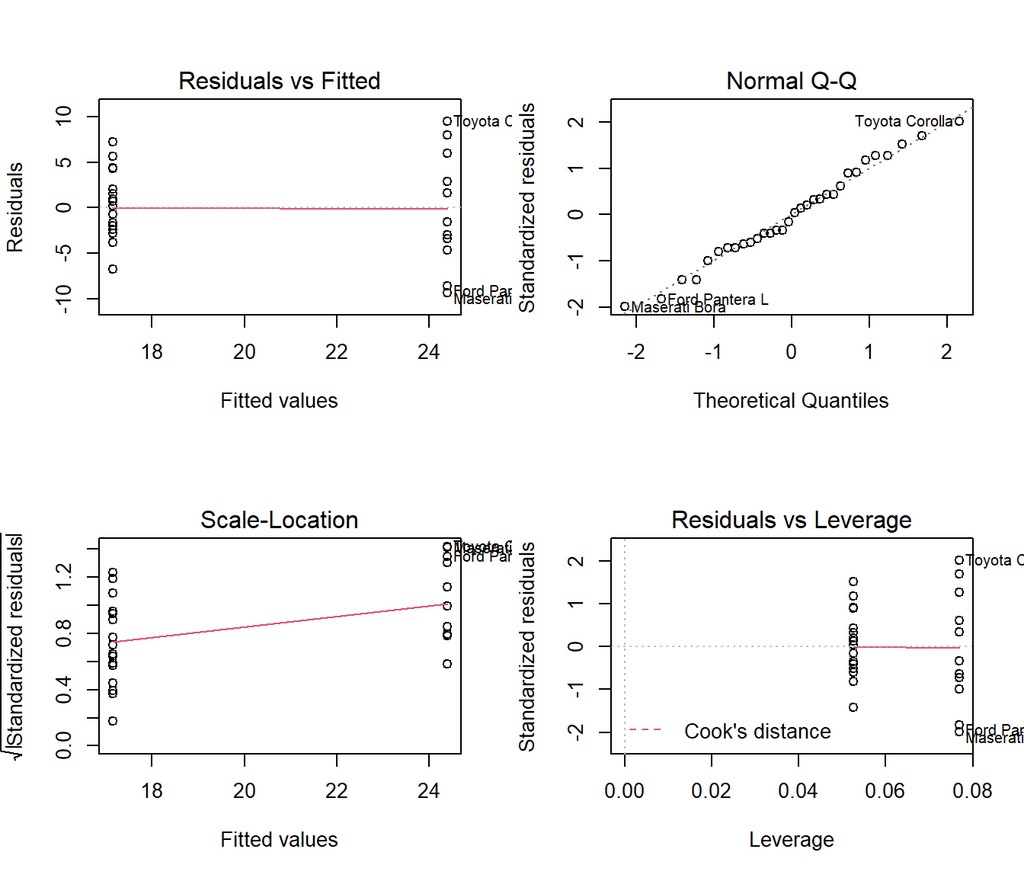

#### Model 2

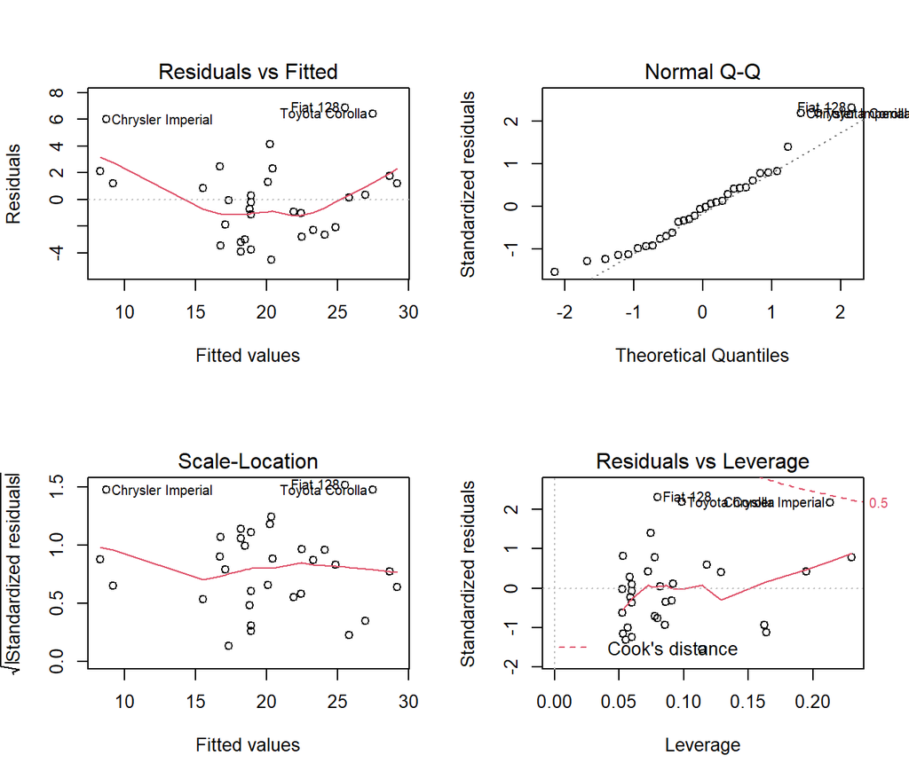